# Prosper Loan Data

## Preliminary Wrangling

> This dataset is about loans and the status of the loans as well as the borrowers.

```python
# import all packages and set plots to be embedded inline
import numpy as np
import pandas as pd
import matplotlib.pyplot as plt
import seaborn as sns
import requests

%matplotlib inline
```

> Load in your dataset and describe its properties through the questions below. Try and motivate your exploration goals through this section.

```python
# Get url for loans csv
url = 'https://s3.amazonaws.com/udacity-hosted-downloads/ud651/prosperLoanData.csv'

# Gather loans df
loans = pd.read_csv(url)
loans.to_csv('data/loans.csv', index=False)
```

```python
loans = pd.read_csv('data/loans.csv')
print(f'Observations: {loans.shape[0]}\nFeatures: {loans.shape[1]}')
loans.head(3)
```

```
Observations: 113937
Features: 81
```

|  | ListingKey | ListingNumber | ListingCreationDate | CreditGrade | Term | LoanStatus | ClosedDate | BorrowerAPR | BorrowerRate | LenderYield | ... | LP_ServiceFees | LP_CollectionFees | LP_GrossPrincipalLoss | LP_NetPrincipalLoss | LP_NonPrincipalRecoverypayments | PercentFunded | Recommendations | InvestmentFromFriendsCount | InvestmentFromFriendsAmount | Investors |
| --- | --- | --- | --- | --- | --- | --- | --- | --- | --- | --- | --- | --- | --- | --- | --- | --- | --- | --- | --- | --- | --- |
| 0 | 1021339766868145413AB3B | 193129 | 2007-08-26 19:09:29.263000000 | C | 36 | Completed | 2009-08-14 00:00:00 | 0.16516 | 0.158 | 0.138 | ... | -133.18 | 0.0 | 0.0 | 0.0 | 0.0 | 1.0 | 0 | 0 | 0.0 | 258 |
| 1 | 10273602499503308B223C1 | 1209647 | 2014-02-27 08:28:07.900000000 | NaN | 36 | Current | NaN | 0.12016 | 0.092 | 0.082 | ... | 0.00 | 0.0 | 0.0 | 0.0 | 0.0 | 1.0 | 0 | 0 | 0.0 | 1 |
| 2 | 0EE9337825851032864889A | 81716 | 2007-01-05 15:00:47.090000000 | HR | 36 | Completed | 2009-12-17 00:00:00 | 0.28269 | 0.275 | 0.240 | ... | -24.20 | 0.0 | 0.0 | 0.0 | 0.0 | 1.0 | 0 | 0 | 0.0 | 41 |

3 rows × 81 columns

### What is the structure of your dataset?

> 113,937 observations with 81 features. I.e. 113,937 rows by 81 columns.

### What is/are the main feature(s) of interest in your dataset?

> CreditGrade, BorrowerAPR, BorrowerRate, EstimatedLoss, EstimatedReturn, ProsperScore, ListingCategory, BorrowerState, EmploymentStatus, IsBorrowerHomeowner, CreditScoreRangeLower, CreditScoreRangeUpper, CurrentCreditLines, OpenCreditLines, InquiriesLast6Months, TotalInquiries, CurrentDelinquencies, DelinquenciesLast7Years, IncomeRange, IncomeVerifiable, and StatedMonthlyIncome.

### What features in the dataset do you think will help support your investigation into your feature(s) of interest?

> CreditGrade, BorrowerAPR, BorrowerRate, EstimatedLoss, EstimatedReturn, ProsperScore, ListingCategory, BorrowerState, EmploymentStatus, IsBorrowerHomeowner, CreditScoreRangeLower, CreditScoreRangeUpper, CurrentCreditLines, OpenCreditLines, InquiriesLast6Months, TotalInquiries, CurrentDelinquencies, DelinquenciesLast7Years, IncomeRange, IncomeVerifiable, and StatedMonthlyIncome.

## Univariate Exploration

> In this section, investigate distributions of individual variables. If you see unusual points or outliers, take a deeper look to clean things up and prepare yourself to look at relationships between variables.

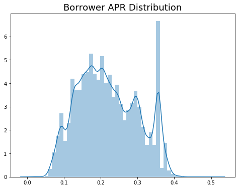

```python
plt.figure(figsize=(8,6))
sns.distplot(
    loans['BorrowerAPR'].dropna(),

);

plt.title('Borrower APR Distribution', size=18);
plt.xlabel('');
```

Surprisingly almost has a normal distribution with a couple peaks and a really large peak between 0.3 and 0.4.

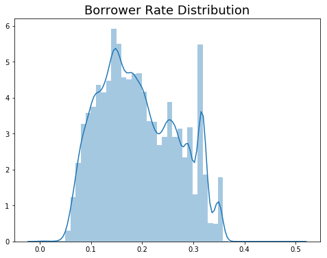

```python
plt.figure(figsize=(8,6))
sns.distplot(
    loans['BorrowerRate'].dropna(),

);

plt.title('Borrower Rate Distribution', size=18);
plt.xlabel('');
```

It is interesting to see that where the borrow rate distribution rises on the graph, it is matched by borrower apr graph.

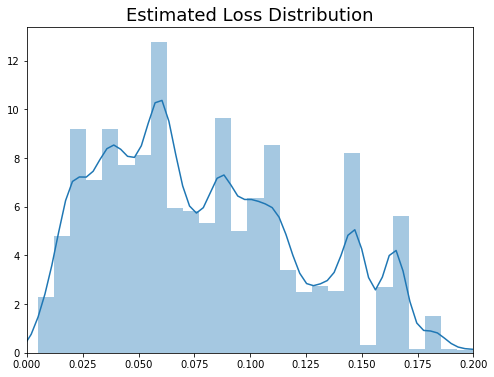

```python
plt.figure(figsize=(8,6))
sns.distplot(
    loans['EstimatedLoss'].dropna(),

);

plt.title('Estimated Loss Distribution', size=18);
plt.xlabel('');
plt.xlim(0,0.2);
```

The estimated loss is definitely right skewed with a few peaks.

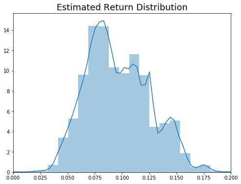

```python
plt.figure(figsize=(8,6))
sns.distplot(
    loans['EstimatedReturn'].dropna(),

);

plt.title('Estimated Return Distribution', size=18);
plt.xlabel('');
plt.xlim(0, 0.2);
```

Estimated Return is actually almost normally distributed.

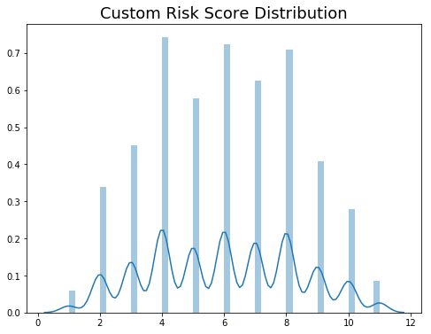

```python
plt.figure(figsize=(8,6))
sns.distplot(
    loans['ProsperScore'].dropna(),

);

plt.title('Custom Risk Score Distribution', size=18);
plt.xlabel('');
```

Probably the closest we have to a normal distribution.

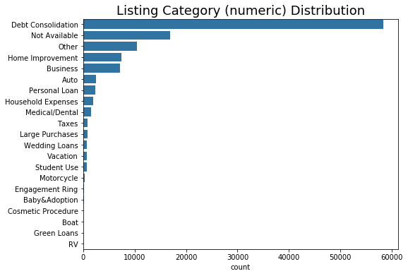

```python
throw = {
    0: 'Not Available',
    1: 'Debt Consolidation',
    2: 'Home Improvement',
    3: 'Business',
    4: 'Personal Loan',
    5: 'Student Use',
    6: 'Auto',
    7: 'Other',
    8: 'Baby&Adoption',
    9: 'Boat',
    10: 'Cosmetic Procedure',
    11: 'Engagement Ring',
    12: 'Green Loans',
    13: 'Household Expenses',
    14: 'Large Purchases',
    15: 'Medical/Dental',
    16: 'Motorcycle',
    17: 'RV',
    18: 'Taxes',
    19: 'Vacation',
    20: 'Wedding Loans'
}

order = loans['ListingCategory (numeric)'].value_counts().index.map(throw)

color = sns.color_palette()[0]

plt.figure(figsize=(8,6))
sns.countplot(
    y=loans['ListingCategory (numeric)'].map(throw),
    color=color,
    order=order,
);

plt.title('Listing Category (numeric) Distribution', size=18);
plt.ylabel('');
```

This was interesting in the sense to see other observations besides only Debt Consolidation.

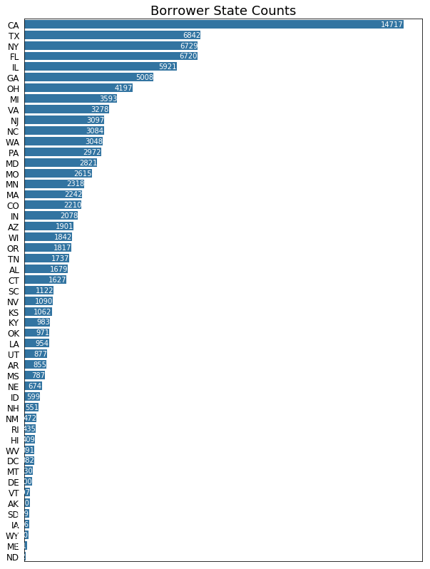

```python
order = loans['BorrowerState'].value_counts().index.tolist()
base_color = sns.color_palette()[0]

plt.figure(figsize=(10,14))

sns.countplot(
    data=loans,
    y='BorrowerState',
    color=base_color,
    order=order,
);

value_counts = loans['BorrowerState'].value_counts()

for i in range(value_counts.shape[0]):
    count = value_counts[i]
    pct_string = value_counts[i]
    plt.text(count+1, i, pct_string, ha='right', va='center', color='w');

plt.tick_params(
    which='both',
    bottom=False,
    top=False,
    left=False,
    labelbottom=False,
    labelsize='large'
);

plt.ylabel('');
plt.xlabel('');
plt.title('Borrower State Counts', size=18);
```

Unsurprisingly, most of the borrowers are from California. What is suprising is that Texas is next on the list.

> Make sure that, after every plot or related series of plots, that you include a Markdown cell with comments about what you observed, and what you plan on investigating next.

## Bivariate Exploration

> In this section, investigate relationships between pairs of variables in your data. Make sure the variables that you cover here have been introduced in some fashion in the previous section (univariate exploration).

BorrowerAPR, BorrowerRate, EstimatedLoss, EstimatedReturn, ProsperScore, ListingCategory, BorrowerState, EmploymentStatus

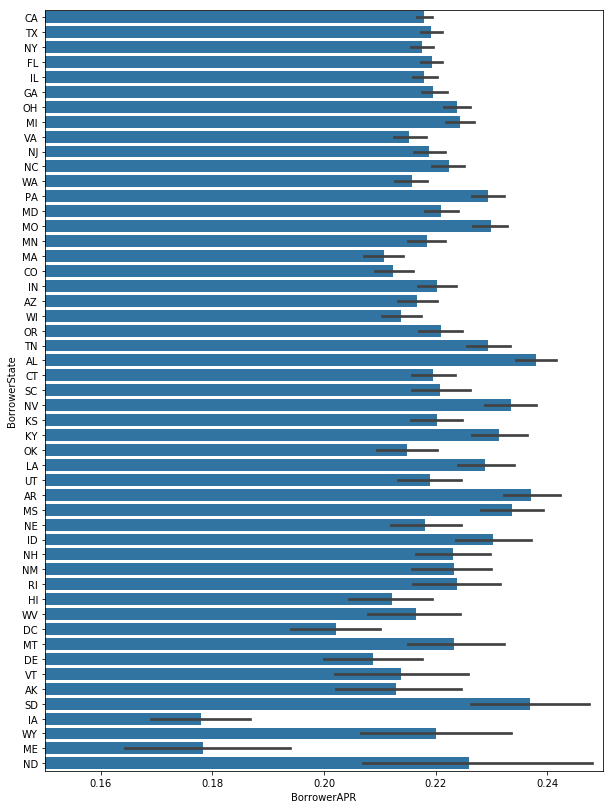

```python
order = loans['BorrowerState'].value_counts().index.tolist()
base_color = sns.color_palette()[0]

plt.figure(figsize=(10,14))

sns.barplot(
    data=loans,
    y='BorrowerState',
    x='BorrowerAPR',
    color=base_color,
    order=order,
);

plt.xlim(0.15,0.25);
```

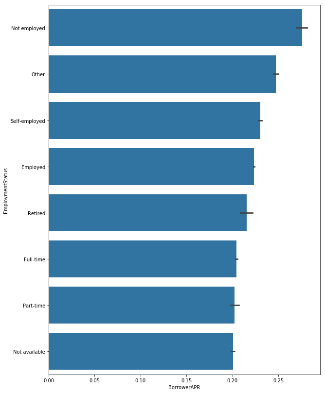

```python
order = loans.groupby('EmploymentStatus')['BorrowerAPR'].mean().sort_values(ascending=False).index.tolist()
base_color = sns.color_palette()[0]

plt.figure(figsize=(10,14))

sns.barplot(
    data=loans,
    y='EmploymentStatus',
    x='BorrowerAPR',
    color=base_color,
    order=order,
);
```

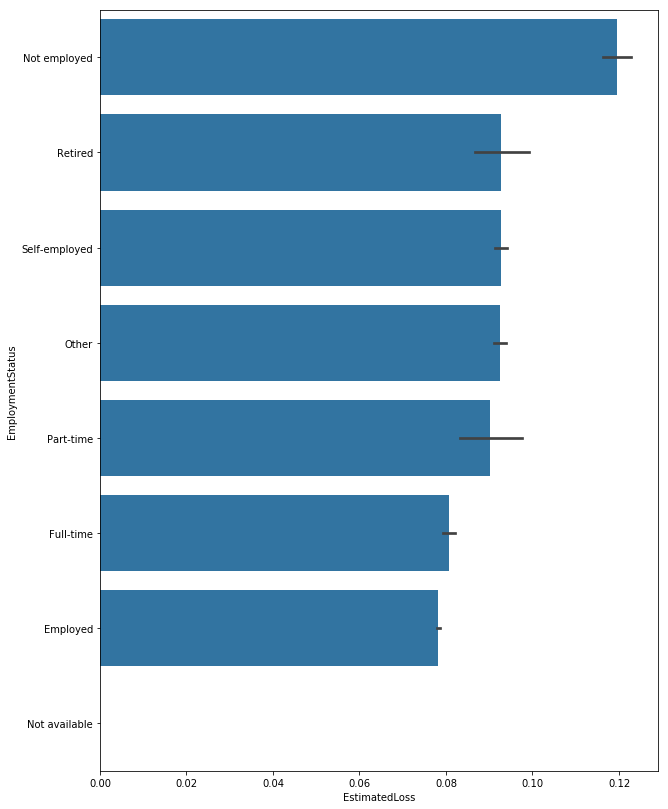

```python
order = loans.groupby('EmploymentStatus')['EstimatedLoss'].mean().sort_values(ascending=False).index.tolist()
base_color = sns.color_palette()[0]

plt.figure(figsize=(10,14))

sns.barplot(
    data=loans,
    y='EmploymentStatus',
    x='EstimatedLoss',
    color=base_color,
    order=order,
);
```

## Multivariate Exploration

> Create plots of three or more variables to investigate your data even further. Make sure that your investigations are justified, and follow from your work in the previous sections.

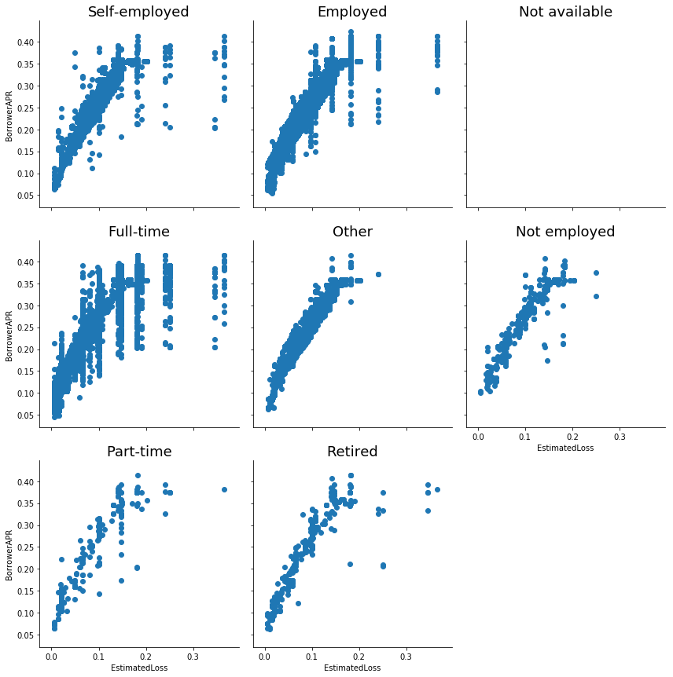

```python
g = sns.FacetGrid(
    data=loans,
    col='EmploymentStatus',
    height=4,
    margin_titles=True,
    col_wrap=3
)
g.map(plt.scatter, 'EstimatedLoss', 'BorrowerAPR');
g.set_titles('{col_name}', size=18);
```

It would make sense that as the estimated loss raises so does the APR, not dependent on employment status. Speaking on that, however, where someone is employed (self-employed, employed, full-time) there is much more variance, most likely because lenders are more lenient sense they can trust the borrower more.

- borrower state
- borrower state count
- borrwer apr
- IsBorrowerHomeowner

```python
loans['IsBorrowerHomeowner'].head(3)
```

```
0     True
1    False
2    False
Name: IsBorrowerHomeowner, dtype: bool
```

[figure not shown]

```python
g = sns.FacetGrid(
    data=loans,
    col='BorrowerState',
    height=4,
    margin_titles=True,
    col_wrap=3
)
g.map(plt.scatter, 'IsBorrowerHomeowner', 'BorrowerAPR');
g.set_titles('{col_name}', size=18);
plt.xticks([0, 1], ['No', 'Yes']);
```

For the most part, being a homeowner does not directly impact your APR. However, in some states, if you are a homeowner, it is possible to get a lower APR; in other states, if you are NOT a homeowner then you can get a lower APR.